# Crisis And Disaster Risks Around The World

# Examining the Somalia chart

- Looking at the risk graph of Somalia, it is possible to say that all risks are quite high, except for the earthquake, which is already the highest risk country examined. The highest risk situation is the risk of not being able to access treatment. The fact that this risk is high poses a great threat to the people living in Somalia both in their daily lives and in disaster situations. Therefore, the first problem to be solved is the problem of not being able to access treatment. This risk is followed by economic dependency. The poor economy may face situations such as the Somali state’s inability to find the strength to help the victims in disaster situations. Measures to be taken for disasters such as floods and tsunamis should follow the efforts to reduce these two risks.

Compared last year’s data with this year’s forecast data. However, since our data containing last year’s data was not clean, the skip command was used first when defining other data. Then, since the column names were not correct, the necessary columns were taken and named. Vulnerability, Hazard & Exposure, Lack of capacity risk ratios are expressed over the percentile. In the existing data, our risk ratios were evaluated out of 50. was not suitable for comparison. However, starting from the equation mentioned at the beginning, the risk ratios in the column were recalculated based on last year’s indicators (Vulnerability, Hazard & Exposure, Lack of capacity).

2022 Inform Risk Data

| InformRisk | Country | lackOfCapacity | Vulnerability | HazardExposure |
| --- | --- | --- | --- | --- |
| 8.2 | Afghanistan | 7.3 | 8.4 | 8.9 |
| 7.8 | Central African Republic | 8.7 | 8.8 | 6.2 |
| 7.9 | Chad | 8.9 | 7.6 | 7.3 |
| 7.6 | Congo DR | 8.1 | 7.4 | 7.4 |
| 6.8 | Ethiopia | 6.8 | 6.4 | 7.3 |
| 6.6 | Iraq | 6.5 | 5.8 | 7.7 |
| 7.0 | Mali | 6.6 | 7.1 | 7.3 |
| 7.2 | Mozambique | 6.3 | 7.6 | 7.8 |
| 7.4 | Niger | 7.6 | 7.3 | 7.3 |
| 6.5 | Nigeria | 6.5 | 5.8 | 7.3 |
| 8.8 | Somalia | 8.8 | 8.8 | 8.9 |
| 8.4 | South Sudan | 9.5 | 8.8 | 7.2 |
| 7.1 | Syria | 5.4 | 7.6 | 8.7 |
| 8.2 | Yemen | 7.9 | 8.2 | 8.4 |

2021 Inform Risk Data

| COUNTRY | RiskValue | HazardExposure | Vulnerability | LackOfCapacity |
| --- | --- | --- | --- | --- |
| Afghanistan | 7.3 | 6.135 | 6.663 | 9.140 |
| Central African Republic | 7.2 | 5.040 | 7.583 | 9.056 |
| Chad | 8.2 | 7.880 | 7.575 | 9.216 |
| Ethiopia | 7.1 | 5.875 | 6.752 | 8.735 |
| Iraq | 6.5 | 5.200 | 5.577 | 8.789 |
| Mali | 7.8 | 7.805 | 6.864 | 8.860 |
| Mozambique | 7.4 | 6.630 | 6.873 | 8.845 |
| Niger | 8.5 | 9.635 | 7.215 | 8.791 |
| Nigeria | 8.4 | 9.820 | 6.446 | 8.858 |
| Yemen | 6.8 | 4.135 | 6.912 | 9.317 |

The two tables above contain separately 2022 and 2021 data. Visualization has been made to draw attention to the separations visually. Visualized graphs of 2021 according to Risk Rate, vulnerability, lack of capacity, hazard Exposure data are given below.

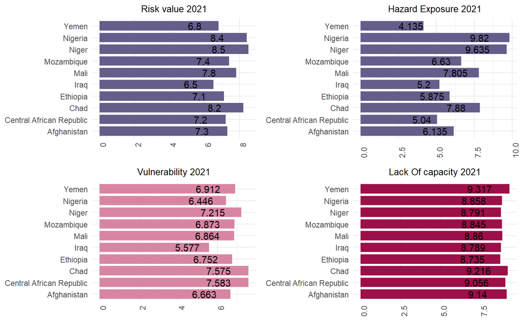

As we mentioned at the beginning of the project, we stated that we would create the Turkey chart after creating the charts for the countries above a certain risk level. We will compare Turkey’s risky disasters with other countries.

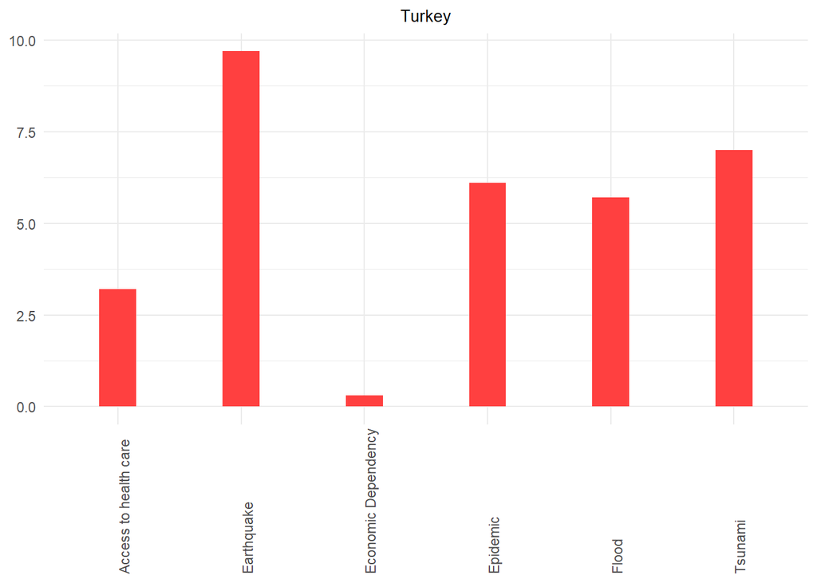

When we consider Turkey, we see that the overall risk ratio is 4.9. This ratio corresponds to the medium class as the risk class. This is good news for Turkey. However, when we look at the risk ratios specifically, we see that the earthquake risk is very high. Turkey’s first priority should be to aim to minimize the damage by taking the necessary precautions against earthquakes. Because the earthquake risk is so high, it shows that a big earthquake can come at any time.

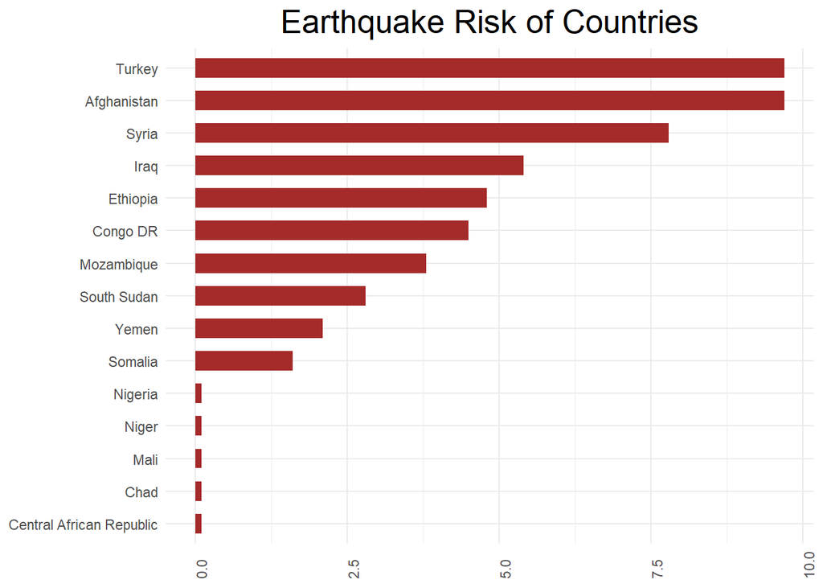

The seriousness of the situation can be understood from the fact that Turkey ranks first, even when compared to the highest risk countries.

The biggest risk after the earthquake in Turkey is the tsunami. Although Turkey is known as an earthquake zone, the threat posed by a tsunami is at a level that cannot be ignored. The probability of a tsunami occurring after the earthquake is also very high. Therefore, taking the necessary precautions for the tsunami will prevent many loss of life and property.

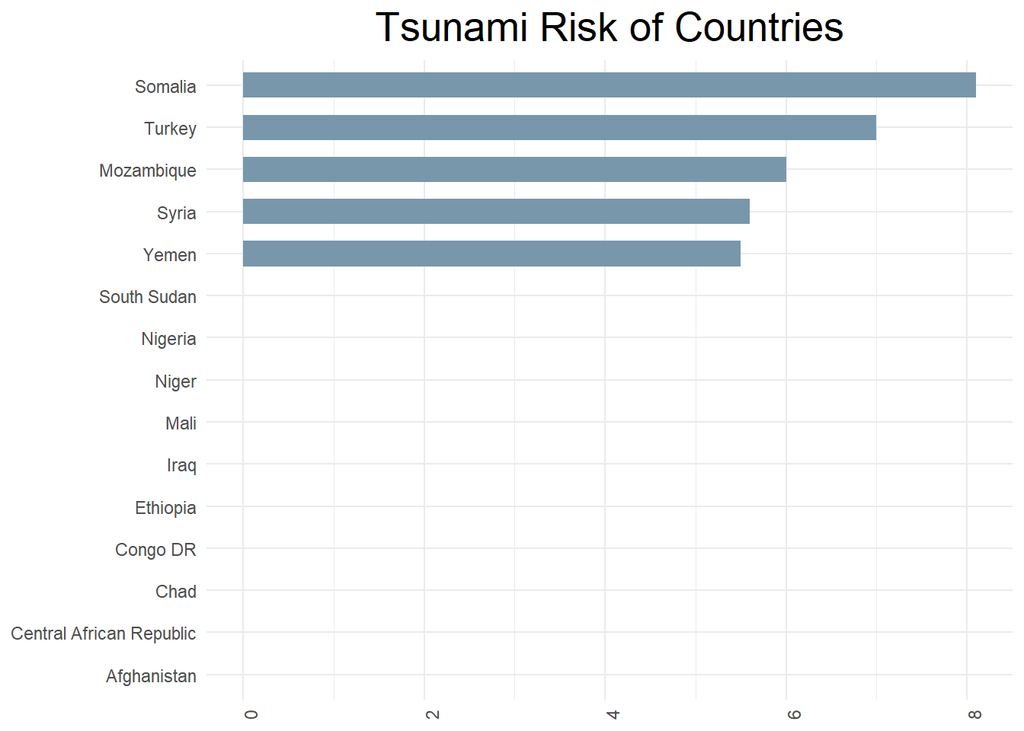

Turkey is an earthquake zone. The ratio and comparison can be seen in the chart above. Earthquake carries the risk of realizing a tsunami as well as its own effects. The tsunami is caused by the shifting of the energy on the ground as a result of the movements. There are more than 90 recorded tsunami data in Turkey. It has been observed regionally in the Aegean Sea, the Marmara Sea and the Mediterranean Sea. No loss or damage has been reported yet. But it needs to be taken seriously. For example, as a result of the researches carried out a few days after the earthquake of 17 August 1999, it was seen that the sea retreated before the earthquake and then rose by creating tsunami waves. Since Turkey is an earthquake country and a big earthquake is expected in the Istanbul region in the coming years, awareness should be raised in terms of tsunami and people should be warned with certain precautions.

# Results

In our project, data was visualized with various graphic types to reach the result. First, the countries in our data were grouped on the basis of which continent and shown on a world map. In this way, by understanding the natural disasters in the continents, he provided a better understanding of the countries. It was thought that it would be good in terms of warning-precaution to include high-risk countries in the study. In the first part, it was stated that the risk ratio is divided into three as Lack of capacity, hazard-exposure, vulnerability. When viewed on the basis of Hazard-exposure, it is divided into two: population and human/natural disaster. A line chart containing the population was made. Based on the population, it was interpreted how many people would be affected by disasters in countries. Before looking at the disaster basis, the general risk ratios were examined to see how the disasters, which are divided into human and natural, affect the countries. In general, hazard-exposure was examined and a bar plot was used for this. Secondly, it was divided into two in terms of Lack of capacity. Government Effective and drinking water. These two separations were analyzed with a bar plot. Lack of capacity was viewed in general. Food availability score and natural disasters of total population of country rates were analyzed in terms of vulnerability. Plotted with the general vulnerability bar plot for more precise information. Each country was graphically analyzed in terms of Access to health care, Earthquake, Economic depency, epidemic, flood, tsunami as man-made and natural disasters. In order to observe the development of these countries and the calculated data, a comparison was made with the risk data in 2021 and interpreted graphically as a table. Lastly, Turkey’s earthquake and tsunami comparison and risk ratios were charted.

# Discussion

At the beginning of the project, it was planned to discuss by giving a warning/precaution according to the risks of the countries and the ratios given when calculating this risk. As a result of the investigations, we will convey our views, the protection, warning and precautionary information we have obtained, such as how much damage will be affected on the basis of disasters. The discussion and recommendations given are based more on the observed results than the research and the information and opinions gained in this project. Natural disasters usually occur spontaneously, but can also be touched by human hands. People can reduce the effects of disasters by taking precautions. The risk ratios of the countries we research are very important. Countries with high risk levels should always be prepared. As we mentioned in the study, certain researches and solution suggestions are presented from the continuous Niger flood disaster. Compared to previous years, it has improved in taking action. In a study, certain strategies were suggested in terms of flooding [1]. Methods of earthquake protection are also emphasized by experts. Earthquakes are caused by the movements of the earth’s crust and are inevitable. Afghanistan is the country most affected by the earthquake in our research. The most recent earthquake occurred on January 24, 2022, with a magnitude of 5. In this respect, it is necessary to raise awareness of people and develop houses and living spaces at a sufficient material level. If there is a coast after the earthquake, the probability of a tsunami is very high. Tsunami is an inevitable disaster. Its measure is to raise awareness and escape to heights.

Our project can be studied by making a full detailed comparison with previous data. In addition, it can be diversified by making more detailed research on the basis of the desired country.